# Bayesian Data Analysis in Julia

Author

Laus Wullum

Published

July 30, 2022

## Relearning Turing.jl

The Julia PPL `Turing.jl` has had some updates. This blog post serves as a very basic introduction on how to work with a `Turing.jl` model.

## Data

We will use a dataset from a chapter on longitudinal data in the **excellent** online book on [Applied Modelling in Drug Development](https://opensource.nibr.com/bamdd/src/02g_longitudinal.html#data) written by statisticians from Novartis.

The data comes from a fictional longitudinal phase II dermatology study, focused on the PASI score, which measures psoriasis severity. Specifically, we will model the treatment effect compared to placebo on the PASI score at week 12, adjusting for baseline scores. For simplicity, we ignore the longitudinal aspect of the study, as the goal is to demonstrate Bayesian inference using `Turing.jl` in Julia with real, non-simulated data.

```julia
## Load packages
using Turing
using CSV
using DataFrames
using TidierData
using TidierPlots
using CategoricalArrays
using FillArrays
using LinearAlgebra


# Load data from the parent folder
adpasi = CSV.read(joinpath("..","..", "data", "longitudinal.csv"), DataFrame)

# Name datasets and filter for PASI endpoint at Week12
pasi_data = @chain adpasi begin
    @filter(TRT01P in ["PBO", "TRT"])
    @filter(PARAMCD == "PASITSCO")
    @arrange(AVISITN)
end

xmat = @chain pasi_data begin
    @filter(AVISIT == "Week 12")
    @mutate(TRT01P1 = TRT01P == "TRT")
    @select(TRT01P1, TRT01P, BASE, AVAL)
end

# Design matrix
covariate_mat = [
    xmat[!, "TRT01P1"] parse.(Float64, xmat[!, "BASE"])
]

# Outcome measurements at week 12
pasi_score_week_12 = xmat[!, "AVAL"]
```

## Overview

```
geom_raincloud
data: inherits from plot
x: inherits from plot
y: inherits from plot
```

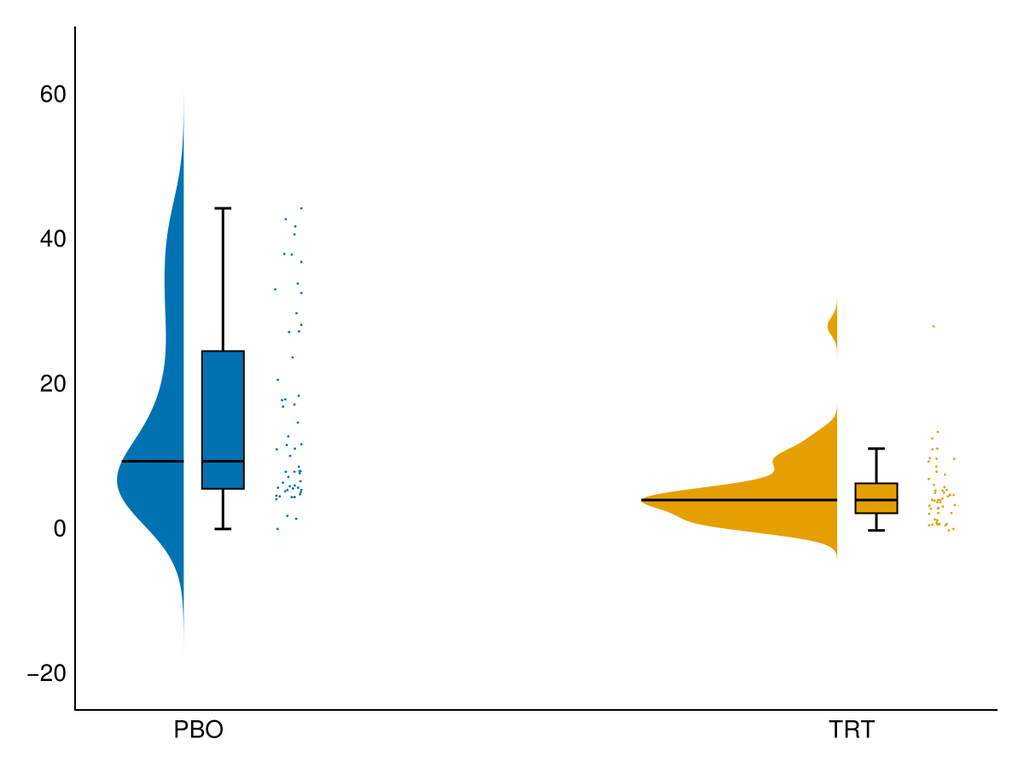

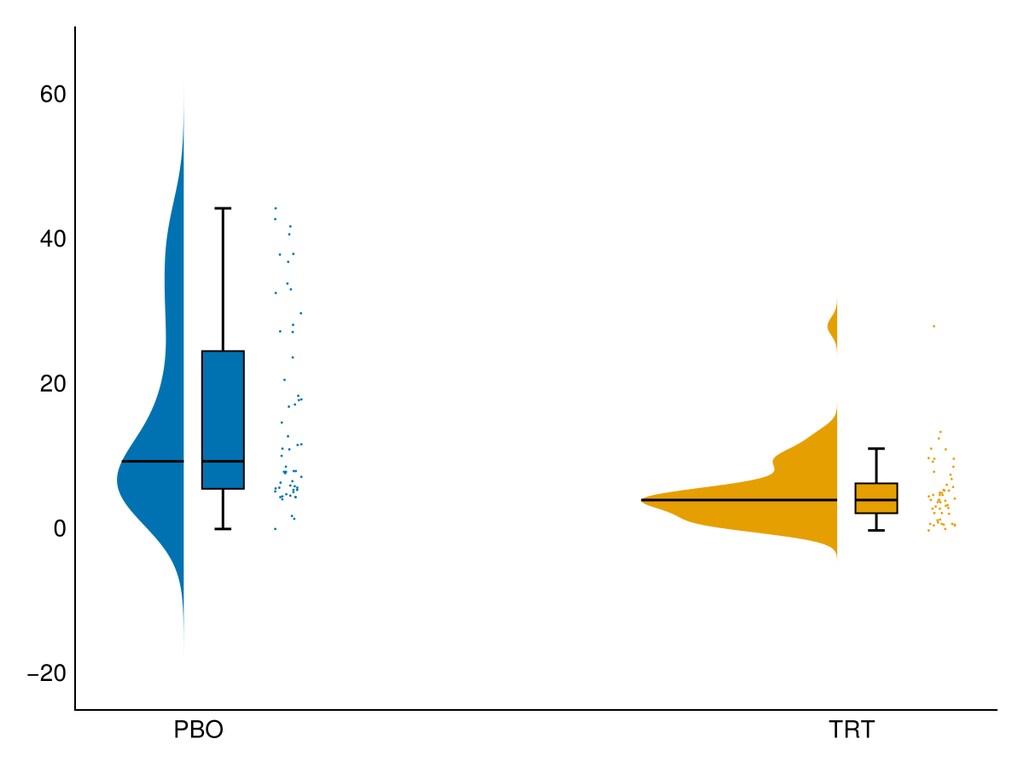

```julia
geom_raincloud = geom_template("geom_raincloud", ["x", "y"], :RainClouds)

plot1 = @chain pasi_data begin
    @filter(AVISIT == "Week 12")
    ggplot(aes(x = :TRT01P, y = :AVAL, color = :TRT01P))
    geom_raincloud(size = 4)
    theme_minimal()
end
```

## Bayesian linear model

We are going to posit the following model, where $A$ denotes treatment and $B$ denotes the baseline PASI score. The specific prior does not concern us.

$$\begin{align}
PASI_i &\sim \mathcal{N}(\alpha + \beta_A A + \beta_B B, \sigma^2)\\
\sigma^2 &\sim \mathcal{N}_+ (0, 10) \\
\beta_A &\sim \mathcal{N}(0, 10) \\
\beta_B &\sim \mathcal{N}(0, 10)\\
\alpha &\sim \mathcal{N}(0, 10)
\end{align}$$

More programatically,

AVAL ~ BASE + TRT01P

## Turing.jl model

In `turing.jl` this becomes

```julia
@model function lin_reg(x)
    sigma_sq ~ truncated(Normal(0, 10); lower=0)
    intercept ~ Normal(0, 10)
    nfeatures = size(x, 2)
    coefficients ~ MvNormal(Zeros(nfeatures), 10.0 * I)
    mu = intercept .+ x * coefficients
    y ~ MvNormal(mu, sigma_sq * I)

    return mean(y)
end
```

## Model object

Now we can define the model unconditional.

```julia
model = lin_reg(covariate_mat)
```

With this we can sample from the prior predictive distribution by.

```julia
pp_data = rand(model)
```

```
(sigma_sq = 5.945744396767607, intercept = 7.065479859666402, coefficients = [7.415558272024761, 0.28503978263641916], y = [12.443114397433822, 20.48768875900952, 20.40865226231607, 27.63441138267089, 22.61920840845327, 10.135942424141762, 11.065394035393465, 11.055779768984966, 7.760617038099545, 7…
```

This yiels a named tuple with parameters drawn and data sampled.

We can plot the data envisioned by our prior specification.

```
geom_raincloud
data: inherits from plot
x: inherits from plot
y: inherits from plot
```

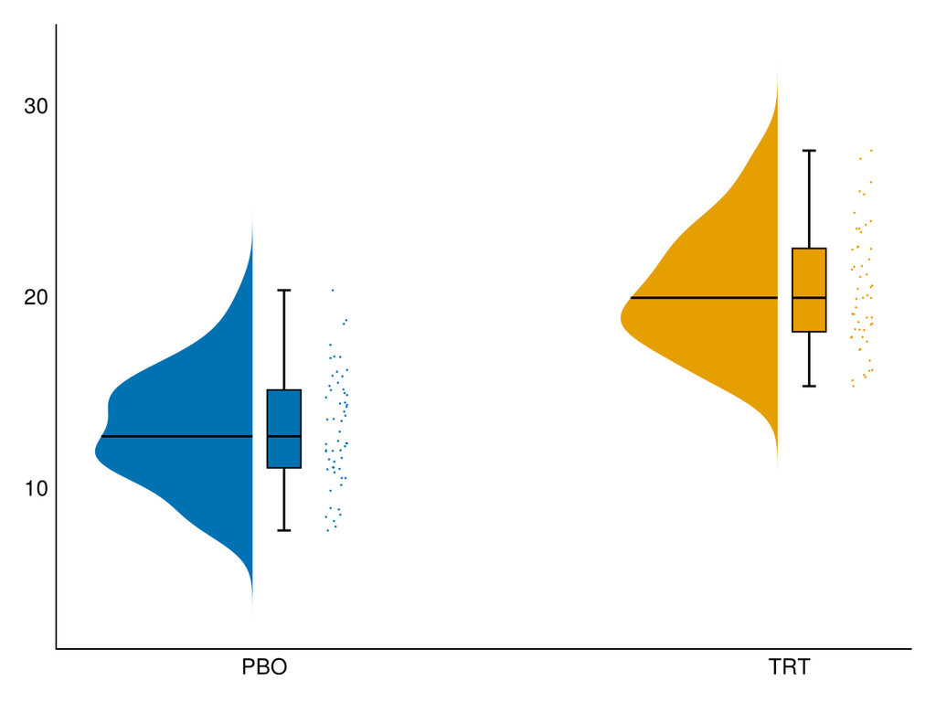

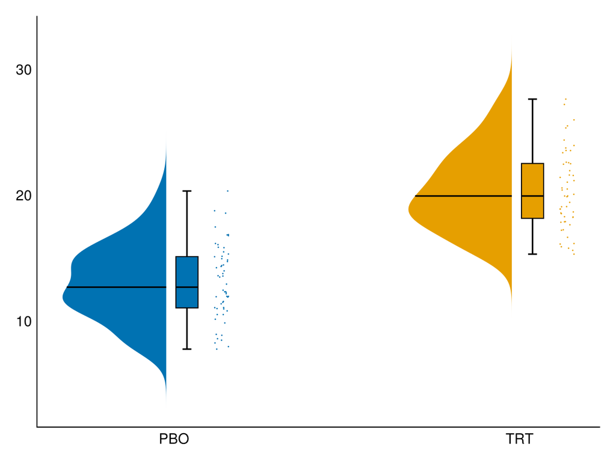

```julia
geom_raincloud = geom_template("geom_raincloud", ["x", "y"], :RainClouds)

@chain xmat begin
    @mutate(AVAL_PP1 = Main.pp_data.y)
    ggplot(aes(x = :TRT01P, y = :AVAL_PP1, color = :TRT01P))
    geom_raincloud(size = 4)
    theme_minimal()
end
```

We can also fix the parameters at specific values in the model.

```julia
params_gen = (sigma_sq = 1, coefficients = [0.1, 0.3], intercept = 1)

model_gen = fix(model, params_gen)

rand(model_gen)
```

```
(y = [5.350734034903162, 5.662247409476079, 10.916095718717838, 13.718536953684298, 11.72904542603359, 7.747811436532083, 6.973795947037776, 5.605299984952084, 3.2288635597051276, 5.84681915829362  …  4.72998007672836, 3.0245092723701124, 5.822898492646764, 8.215762628413277, 5.794527864935357, 2.89…
```

If we have observed data, we can posit a conditional model.

```julia
model_cond = model | (y = pasi_score_week_12,)
```

```
DynamicPPL.Model{typeof(lin_reg), (:x,), (), (), Tuple{Matrix{Float64}}, Tuple{}, DynamicPPL.ConditionContext{@NamedTuple{y::Vector{Float64}}, DynamicPPL.DefaultContext}}(lin_reg, (x = [0.0 16.0; 1.0 20.3; … ; 1.0 21.8; 1.0 19.1],), NamedTuple(), ConditionContext((y = [36.7, 2.0, 5.9, 3.8, 0.5, 3.9,…
```

This can be used to perform inference.

```julia
post_inf_chain = sample(model_cond, NUTS(), 1000)
```

```
┌ Info: Found initial step size
└   ϵ = 0.0015625
Sampling:   2%|█                                        |  ETA: 0:00:04Sampling: 100%|█████████████████████████████████████████| Time: 0:00:01
```

```
Chains MCMC chain (1000×16×1 Array{Float64, 3}):
Iterations        = 501:1:1500
Number of chains  = 1
Samples per chain = 1000
Wall duration     = 18.43 seconds
Compute duration  = 18.43 seconds
parameters        = sigma_sq, intercept, coefficients[1], coefficients[2]
internals         = lp, n_steps, is_accept, acceptance_rate, log_density, hamiltonian_energy, hamiltonian_energy_error, max_hamiltonian_energy_error, tree_depth, numerical_error, step_size, nom_step_size
Summary Statistics
       parameters      mean       std      mcse   ess_bulk   ess_tail      rha ⋯
           Symbol   Float64   Float64   Float64    Float64    Float64   Float6 ⋯
         sigma_sq   59.4458    4.9628    0.1814   737.7216   578.8572    1.000 ⋯
        intercept   11.8706    2.1834    0.0868   639.8011   518.2833    0.999 ⋯
  coefficients[1]   -8.6119    1.3676    0.0559   602.1143   425.3895    0.999 ⋯
  coefficients[2]    0.1215    0.1011    0.0038   694.5194   560.7130    1.000 ⋯
                                                               2 columns omitted
Quantiles
       parameters       2.5%     25.0%     50.0%     75.0%     97.5%
           Symbol    Float64   Float64   Float64   Float64   Float64
         sigma_sq    50.2749   56.0566   59.2143   62.7478   69.4691
        intercept     7.7763   10.3673   11.8315   13.3302   16.0863
  coefficients[1]   -11.2052   -9.4768   -8.6697   -7.7117   -5.9169
  coefficients[2]    -0.0730    0.0494    0.1217    0.1901    0.3155
```

The samples are collected into an `MCMCchain.jl` object, which can be used for convergence diagnostics

To obtain posterior predictive samples we call predict on the model using the posterior draws.

```julia
predict(model, post_inf_chain)
```

```
Chains MCMC chain (1000×108×1 Array{Float64, 3}):
Iterations        = 1:1:1000
Number of chains  = 1
Samples per chain = 1000
parameters        = y[1], y[2], y[3], y[4], y[5], y[6], y[7], y[8], y[9], y[10], y[11], y[12], y[13], y[14], y[15], y[16], y[17], y[18], y[19], y[20], y[21], y[22], y[23], y[24], y[25], y[26], y[27], y[28], y[29], y[30], y[31], y[32], y[33], y[34], y[35], y[36], y[37], y[38], y[39], y[40], y[41], y[…
internals         =
Summary Statistics
  parameters      mean       std      mcse    ess_bulk    ess_tail      rhat   ⋯
      Symbol   Float64   Float64   Float64     Float64     Float64   Float64   ⋯
        y[1]   13.9302    7.7624    0.2590    902.6306    906.1256    0.9998   ⋯
        y[2]    5.8694    7.6377    0.2467    956.8902    963.8516    1.0030   ⋯
        y[3]    6.9514    8.0401    0.2807    812.7577    979.4179    1.0008   ⋯
        y[4]    8.9743    7.8315    0.2619    896.3241    815.6239    0.9997   ⋯
        y[5]    6.9256    7.7686    0.2498    969.5620    906.2947    1.0013   ⋯
        y[6]   15.5112    8.0100    0.2680    888.3693    931.6873    1.0018   ⋯
        y[7]   13.6694    7.8071    0.2500    977.3993   1021.8484    0.9999   ⋯
        y[8]   13.7973    7.8567    0.2683    861.3707    943.7586    0.9996   ⋯
        y[9]   13.3492    8.0236    0.2472   1052.4898    991.6390    1.0003   ⋯
       y[10]   13.8125    7.7583    0.2391   1053.4703    980.8705    0.9993   ⋯
       y[11]    7.0555    7.8799    0.2450   1035.8296    868.2807    1.0001   ⋯
       y[12]    4.8385    7.7029    0.2502    947.8795    944.3411    0.9999   ⋯
       y[13]   13.8627    7.8056    0.2516    963.2674    943.7586    1.0000   ⋯
       y[14]    6.3663    7.9670    0.2556    976.4722    977.6814    1.0046   ⋯
       y[15]   13.2084    7.4809    0.2270   1082.4542    906.1256    0.9993   ⋯
       y[16]   14.8200    7.5804    0.2394   1002.6456    943.7586    1.0029   ⋯
       y[17]   14.5661    8.0975    0.2608    947.1946    982.7992    0.9997   ⋯
       y[18]    4.3030    7.8558    0.2558    942.2937   1015.6811    1.0049   ⋯
       y[19]   14.5144    7.6247    0.2450    966.3331    908.3655    1.0023   ⋯
       y[20]    5.7790    7.8771    0.2531    968.8276    971.6794    1.0017   ⋯
       y[21]   15.1518    7.7619    0.2487    970.6578    807.0571    1.0003   ⋯
       y[22]   14.5107    7.5301    0.2528    890.4250    915.3549    0.9991   ⋯
       y[23]   14.2778    8.0578    0.2571    990.5276    848.2734    0.9992   ⋯
      ⋮           ⋮         ⋮         ⋮          ⋮           ⋮          ⋮      ⋱
                                                    1 column and 85 rows omitted
Quantiles
  parameters       2.5%     25.0%     50.0%     75.0%     97.5%
      Symbol    Float64   Float64   Float64   Float64   Float64
        y[1]    -1.0677    8.5496   13.8569   19.0678   29.1246
        y[2]    -8.3045    0.7000    5.6944   10.9398   20.5786
        y[3]    -9.6234    1.5983    6.9414   12.5401   22.2867
        y[4]    -6.1556    3.7657    9.1612   14.1261   24.2393
        y[5]    -8.1186    1.4088    6.6921   12.3556   22.0755
        y[6]    -0.6255   10.2666   15.5954   20.9539   31.7059
        y[7]    -1.5310    8.5781   13.5077   18.8118   29.2659
        y[8]    -0.8773    8.5049   13.7814   18.6332   29.7516
        y[9]    -2.9205    8.1136   13.3701   18.7567   28.9926
       y[10]    -1.9068    8.6400   13.7743   19.1377   28.9887
       y[11]    -8.4473    1.6639    7.0582   12.1801   23.0921
       y[12]   -10.0991   -0.3561    4.6333   10.0225   20.2396
       y[13]    -1.2436    8.3955   13.8132   19.1446   29.0079
       y[14]    -9.3554    1.1170    6.4572   11.8563   21.4153
       y[15]    -1.0084    8.1577   12.8237   18.2235   27.8568
       y[16]     0.5683    9.8812   14.8698   19.8926   30.3438
       y[17]    -1.6841    9.1788   14.6087   19.8509   30.3065
       y[18]   -10.8019   -1.1981    4.4422    9.7860   19.3089
       y[19]    -0.2360    9.4057   14.5411   19.5608   28.8992
       y[20]    -8.5626   -0.0834    5.6969   11.0859   20.9126
       y[21]    -0.6736   10.1207   15.1452   20.2919   30.3570
       y[22]    -0.1183    9.1469   14.6495   19.6111   28.8208
       y[23]    -1.9075    9.0892   14.1527   19.4446   31.8881
      ⋮           ⋮          ⋮         ⋮         ⋮         ⋮
                                                  85 rows omitted
```

We can also obtain the generated quantities as in STAN. Here we obtain the results from the `return` statement within the `Turing.jl` model.

```julia
generated_quantities(model, post_inf_chain)
```

```
1000×1 Matrix{Float64}:
 10.75341475458214
  9.678382971421513
  8.74340199695126
 10.601352864042424
  8.693646118498267
 10.061552429187211
  9.840577576278143
  9.61594359280235
 12.411084693028211
 10.659947591903418
 10.729258695750591
 11.540965548771007
  9.165613048993492
  ⋮
 10.665099987478436
 12.008250183825638
 10.089487059443389
  9.43548415234166
 10.142359712262888
  8.901784195086716
  8.254020852393527
  9.913314687071997
  9.87086190688091
  8.697971472579914
  8.67603947213954
  9.79464839053165
```